# Point Pattern Analysis

GEOG 364 Lab 7

# Lab Set Up

```r
#------------------------------------------------------------------
#                     KNITR SETUP
#------------------------------------------------------------------
knitr::opts_chunk$set(
  message = FALSE,
  warning = FALSE,
  echo = TRUE,
  collapse = TRUE,
  strip.white = TRUE,
  cache = TRUE,
  fig.align = "center",
  results = "hold"
)

options(
  verbose = FALSE,
  scipen = 999 # scientific notation OFF
)

#-----------------------------------------------------------------#
#                     LIBRARIES
#-----------------------------------------------------------------#
# Document Creation
library(knitr)
library(downlit)
library(styler) # tidys code chunks
# run styler::tidy_active_file() or style_dir()
# or go to Addins -> Styler

# Visualization
library(ggplot2)
library(cowplot)
library(RColorBrewer)
library(stargazer)
library(skimr)

# Non-Spatial Data
library(tidyverse)
library(skimr)
library(car)

# Spatial
library(sp)
library(sf)
library(spdep)
library(tmap)
library(USAboundaries)
library(units)
library(elevatr)
library(spatstat)
library(raster)
library(maptools)

#-----------------------------------------------------------------#
#                     GGPLOT THEME
#-----------------------------------------------------------------#
theme_set(theme_void() +
  theme(
    plot.title = element_text(hjust = 0.5), # center title/subtitle
    plot.subtitle = element_text(hjust = 0.5)
  ))
```

## Screenshot

[figure not shown]

```r
knitr::include_graphics("lab7_screenshot.png")
```

## Explanation

I used the **robobook** theme from the **rmdformats** package along with the built-in **rstudio** syntax highlighter. The relevant github page can be found [here](https://github.com/juba/rmdformats)

I also utilized the YAML `output:css:bun_readable.css` parameter to attach my personal modified portion of basic **bootstrap** framework for some additional color and style utilities.

**Citation**  
Yihui Xie and Christophe Dervieux and Emily Riederer (2020). R Markdown Cookbook. Chapman and Hall/CRC. ISBN 9780367563837. https://bookdown.org/yihui/rmarkdown-cookbook.

# Fossil Data Analysis

## Download

```r
# -------------------------------------------------------------------------------------
#                              DATA IMPORT & SET-UP
# -------------------------------------------------------------------------------------
url <- "https://raw.githubusercontent.com/hgreatrex/GEOG364_Labs/master/Lab_4/PA_fossils.csv"

# Save to project, set name with destfile=" "
download.file(url, destfile = "PA_fossils.csv", verbose = TRUE)
df.fossils <- read.csv("PA_fossils.csv") # loads into session

rm(url) # clean up RStudio
```

## Data Description

```r
#---------------------------------------------------------------------------------
#                             DATA OVERVIEW
#                          packages: tidyverse
#---------------------------------------------------------------------------------
head(df.fossils)
```

|  | Key | Name | Period | Long | Lat |
| --- | --- | --- | --- | --- | --- |
| 1 | 1 | Planoendothyra | Missourian | -79.99611 | 40.44056 |
| 2 | 2 | Leptomitus | Dyeran | -76.30583 | 40.03778 |
| 3 | 3 | Orbiculoidea | Eifelian | -78.38917 | 40.42722 |
| 4 | 4 | Lingula | Eifelian | -78.27167 | 40.47833 |
| 5 | 5 | Favosites | Givetian | -77.25000 | 40.50000 |
| 6 | 6 | Truncalosia | Eifelian | -77.86028 | 40.79333 |

```r
stargazer(df.fossils,
  type = "html",
  title = "Summary Statistics",
  summary = TRUE,
  digits = 0,
  iqr = TRUE,
  summary.logical = TRUE,
  covariate.labels = c("ID", "Longitude", "Latitude")
)
```

**Summary Statistics**

[output not shown]

```r
#--printed inline----------------
dims <- dim(df.fossils)
nams <- names(df.fossils)
missims <- df.fossils %>%
  filter(Period == "Mississippian") %>%
  nrow()
```

### Background

[figure not shown]

[The Paleobiology Database (PBDB)](https://paleobiodb.org/#/) is a public database of paleontological data that anyone can use, maintained by an international non-governmental group of paleontologists.

It contains published data on the taxonomy, and temporal and geographic distributions of fossil occurrences. It also contains bibliographic data to which all of the other data types are linked.

**Who**  
The Paleobiology Database (PBDB) organized by a non-governmental, non-profit group of volunteer professional and graduate student paleontologists. Those without graduate-level training may still be able to contribute under the guidance of an authorized member.

**When**  
The PBDB originated from the NCEAS-funded Phanerozoic Marine Paleofaunal Database initiative (1998 – 2000).  
During the periods of 2000 – 2008 and 2010 – 2013, it received funding from the US National Science Foundation has also received funding from the Australian Research Council.

**Limitations**

1. **Sources:** Reports may be spatially biased as contributions are voluntary
2. **Data Entry** errors are possible

**License**  
The PBDB is publically available and may be used freely with attribution (i.e., citation) under a CC BY 4.0 International License.

**How to Cite**  
You can cite the specific Data Archive or the specific download including with it the date and parameters of the download. The example given they give is below.

**Citation**  
The data were downloaded from the Paleobiology Database on 13 December, 2013, using the group name ‘marine’ and the following parameters: time intervals = Eocene and Oligocene, region = Europe, paleoenvironment = marine, Order = Cetacea.

### Parameters

**Object of Observation:** Plants or animals from the *Mississippian period* located in present-day Pennsylvania  
**Object of Analysis** *Mississippian period* *fossils* found, reported, and entered into the PBDB within Pennsylvania  
**Data-set Population** Fossils of any time period recorded in the PBDB and found within PA as of the date of `PA_fossils.xlsx` download  
**Mark/Variable** Yes, see section Data Description for full list

## Make Spatial

```r
#-------------------------------------------------------------------------------------
#                                SPATIAL
#                   packages: USAboundaries, elevatr
#-------------------------------------------------------------------------------------
st.pa_border <- st_transform(us_states(states = "pennsylvania"), 6346)

elevation.utm <- get_elev_raster(st.pa_border, z = 5, clip = "locations")

#--------------------------------------------------------------------------------------
#                         CONVERT FOSSIL DATA
#---------------------------------------------------------------------------------------
sf.fossils <- st_as_sf(df.fossils, coords = c("Long", "Lat"), crs = 4326) %>%
  st_transform(sf.fossils, crs = 26918)

# Check All In Same Projection
proj.pa_border <- raster::projection(st.pa_border)
proj.elevation <- raster::projection(elevation.utm)
proj.fossils <- raster::projection(sf.fossils)
```

**Projections**  
**PA State Border:** +proj=utm +zone=17 +ellps=GRS80 +towgs84=0,0,0,0,0,0,0 +units=m +no_defs  
**Fossils Data:** +proj=utm +zone=18 +datum=NAD83 +units=m +no_defs  
**Elevation Raster:** +proj=utm +zone=17 +ellps=GRS80 +units=m +no_defs

```r
# Fix Projections
st.pa_border <- st_transform(st.pa_border, crs(sf.fossils))
elevation.utm <- projectRaster(elevation.utm, crs = crs(sf.fossils))
# check
proj.pa_border <- raster::projection(st.pa_border)
proj.elevation <- raster::projection(elevation.utm)
```

**Projections**  
**PA State Border:** +proj=utm +zone=18 +datum=NAD83 +units=m +no_defs  
**Fossils Data:** +proj=utm +zone=18 +datum=NAD83 +units=m +no_defs  
**Elevation Raster:** +proj=utm +zone=18 +datum=NAD83 +units=m +no_defs  
The data has been converted to **NAD83 / UTM zone 18N** with units in **meters.**

## Plot tmap

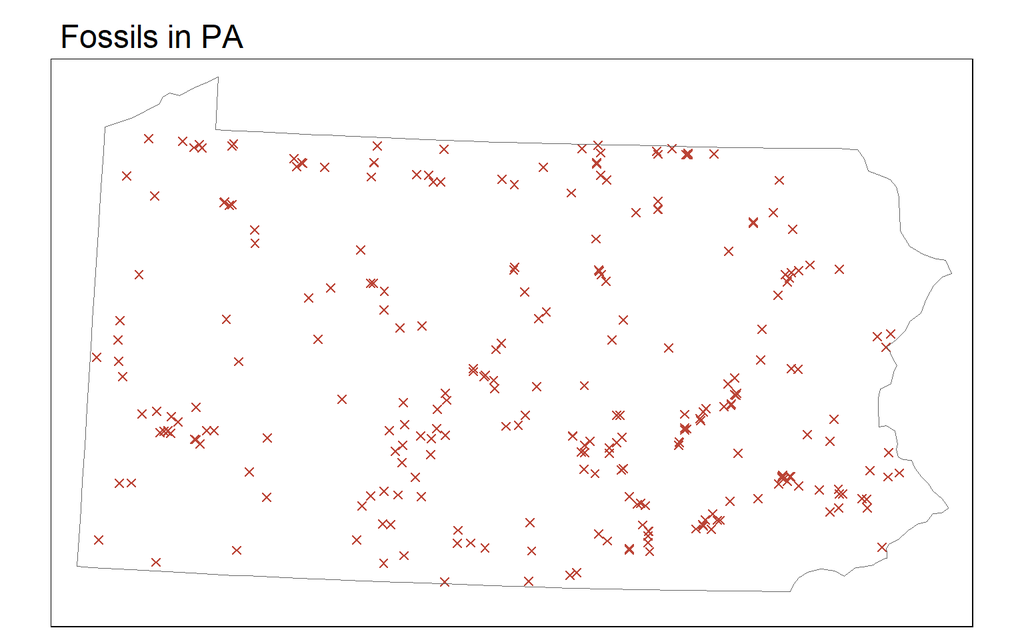

```r
tmap_mode("plot") # Set static plot mode

p.tmap <- tm_shape(sf.fossils) + # Add Fossil data
  tm_dots(col = "#BB4436", size = 0.2, shape = 4) +
  tm_shape(st.pa_border) + # Add state borders
  tm_borders(lwd = .33) +
  tm_layout(
    main.title = "Fossils in PA",
    inner.margins = c(0.08, 0.05, 0.14, 0.08)
  )
p.tmap
```

# Point Pattern Analysis

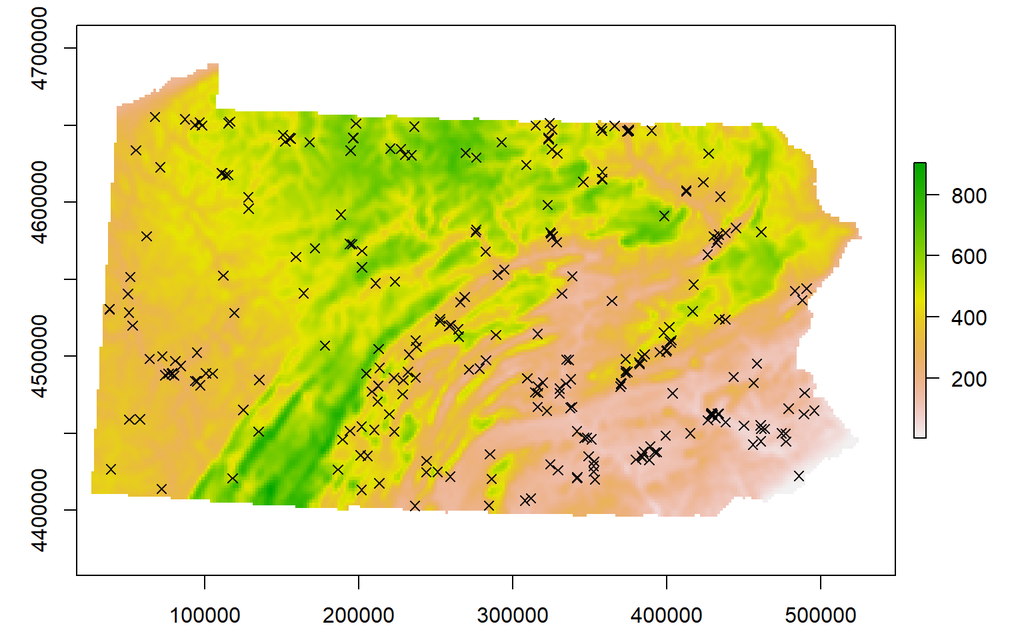

```r
# Converts stateowin to a "window" file format
state.window <- as.owin(st.pa_border)

# Turn sf data into a ppp format, then set the window
ppp.fossils <- as.ppp(sf.fossils)
Window(ppp.fossils) <- state.window

# plot
par(mar = c(2.5, 3, 1, 1))
plot(elevation.utm)
plot(ppp.fossils,
  use.marks = F,
  cex = 1,
  pch = 4,
  lwd = 1.3,
  add = TRUE,
  main.title = "Fossils against Elevation in PA",
  xaxt = "n",
  yaxt = "n"
)
```

The data appears to be spatially dependent. There are several clusters, most notably in the Southeastern region. Clustering is considered *positive autocorrelation.* There are regions of dispersal as well, notably in the central to North-central region, which would be *negative autocorrelation.*

It is likely that there are several factors at play here.

1. **First Order Autocorrelation:** This is a cause of clustering by correlation with itself, i.e., the presence of one observation increases the chances of another observation nearby. This makes sense for fossils because the plants and animals they come from were also first-order autocorrelated.
2. **Second Order Autocorrelation:** This is a cause of clustering by correlation with some other (known or unknown) factor. For example, the fossils are constrained to certain areas because the fossilization process has specific environmnetal requirements to work.
3. **Randomness:** In empirical research, stochastic processes are always present to some degree. It’s possible the observed pattern is entirely due to randomness.

## Centrography

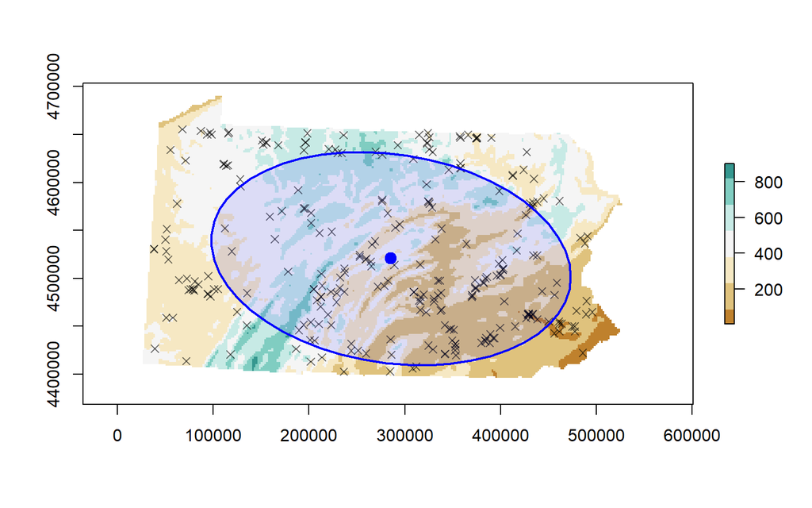

```r
#-------------------------------------------------------------------------------------
#                                CENTROGRAPHY
#                       packages: RColorBrewer, car
#-------------------------------------------------------------------------------------
mycolors <- brewer.pal(n = 11, name = "BrBG")[-c(1, 2, 10, 11)]
plot(elevation.utm,
     col = mycolors
     )

dataEllipse(ppp.fossils$x, ppp.fossils$y,
  levels = 0.68,
  fill = TRUE,
  fill.alpha = 0.1, # Fill the ellipse with transparent grey
  pch = 4,
  cex = 1, # little x's
  xlab = "x (m)",
  ylab = "y (m)",
  col = c(rgb(red = 0, green = 0, blue = 0, alpha = 0.5), "blue"),
  add = TRUE
)
```

**Standard Ellipse:** An elliptical region around the spatial average (center) of the data and encapsulates any given amount of spatial spread.

- Because it is standardized, it can more easily be used for comparison with other data sets.
- Approximately 68% of points fall within the ellipse given by `levels = 0.68`

## Point Pattern Autocorrelation

### Density-Based

#### Global

```r
#-------------------------------------------------------------------------------------
#                                GLOBAL
#                       packages: spatstat
#-------------------------------------------------------------------------------------
area <- area.owin(state.window) / (1000 * 1000) # convert m^2 to km^2
```

#### Local: Kernel

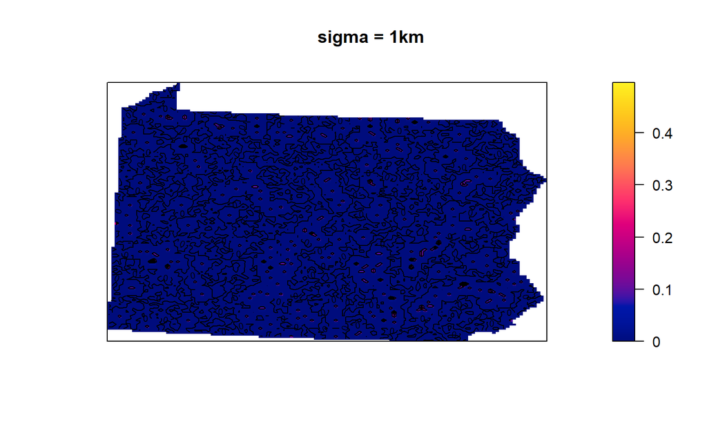

```r
#-------------------------------------------------------------------------------------
#                                LOCAL
#-------------------------------------------------------------------------------------
# R will work in metres by default, let's switch to km
ppp.fossils_km <- rescale(ppp.fossils, 1000, "km")

# Using varying bandwiths bandwidth (sigma)
ker.density_1km <- density(ppp.fossils_km, sigma = 1)
ker.density_10km <- density(ppp.fossils_km, sigma = 10)
ker.density_100km <- density(ppp.fossils_km, sigma = 100)

plot(ker.density_1km, main = "sigma = 1km", las = 1)
contour(ker.density_1km, add = TRUE)
```

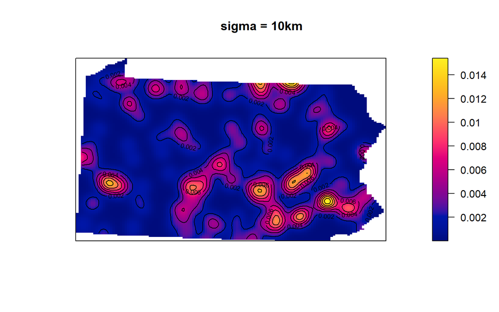

```r
plot(ker.density_10km, main = "sigma = 10km", las = 1)
contour(ker.density_10km, add = TRUE)
```

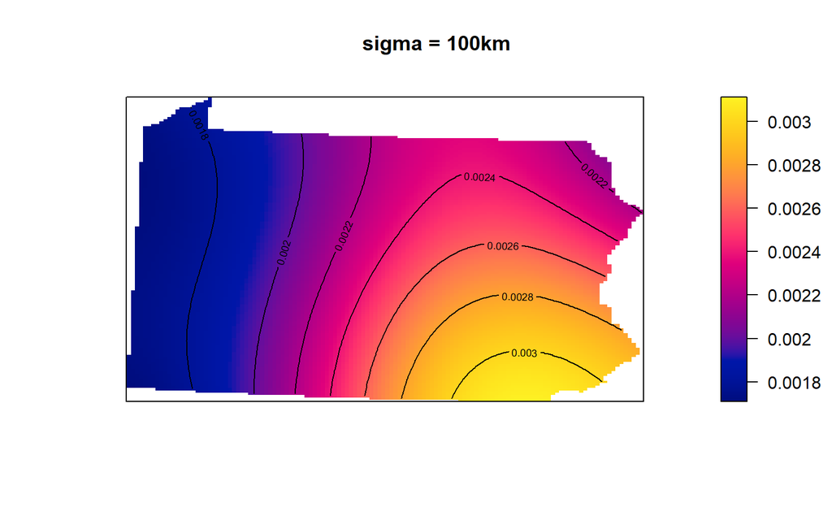

```r
plot(ker.density_100km, main = "sigma = 100km", las = 1)
contour(ker.density_100km, add = TRUE)
```

- **Small Sigma:** Appears similar to what is expected from an independent random process (IRP), but still possible for some first or second order effects.
- **Large Sigma:** Appears distinctly brightest in the Southeast area and steadily decreases towards the Northwest. This type of regular pattern is what is expected from spatial autocorrelation.

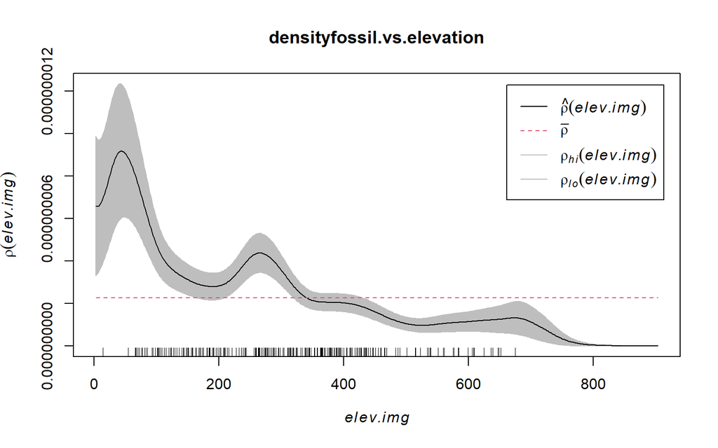

```r
#-------------------------------------------------------------------------------------
#                       packages: maptools, spatstat
#-------------------------------------------------------------------------------------
# convert elevation to a special format
elev.img <- as.im.RasterLayer(elevation.utm)

# calculate the relationship
densityfossil.vs.elevation <- rhohat(unmark(ppp.fossils), elev.img)

plot(densityfossil.vs.elevation)
```

The grey region is an estimate of uncertainty. With proper experiment design, we would expect the true population value to be within that region most of the time, although it could potentially be anywhere.

### Distance-Based

#### Global: Nearest Neighbor

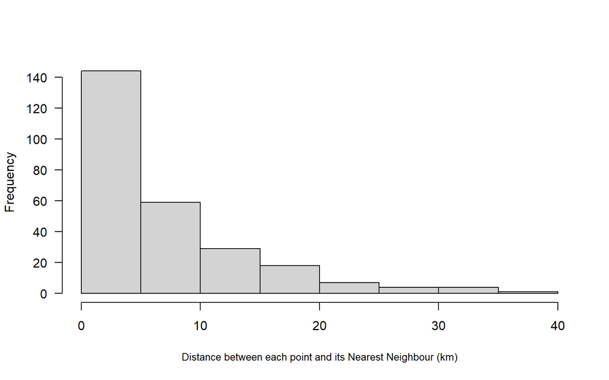

```r
# For each point, nndist calculates the distance to the nearest point
nn.fossils <- nndist(ppp.fossils_km)

# plot
hist(nn.fossils,
  main = NULL, las = 1,
  xlab = list("Distance between each point and its Nearest Neighbour (km)", cex = .8)
)
```

```r
# look at the summary
skim(nn.fossils)
```

Data summary

| Name | nn.fossils |
| --- | --- |
| Number of rows | 266 |
| Number of columns | 1 |
| _______________________ |  |
| Column type frequency: |  |
| numeric | 1 |
| ________________________ |  |
| Group variables | None |

**Variable type: numeric**

| skim_variable | n_missing | complete_rate | mean | sd | p0 | p25 | p50 | p75 | p100 | hist |
| --- | --- | --- | --- | --- | --- | --- | --- | --- | --- | --- |
| data | 0 | 1 | 6.99 | 7.2 | 0.02 | 1.64 | 4.65 | 9.33 | 35.21 | ▇▃▁▁▁ |

**75% are closer than** 9.33km  
**The mean** distance is 6.99km

**H<sub>0</sub>:** The points are randomly distributed  
**H<sub>A</sub>:** The points are significantly more dispersed or significantly more clustered than expected (two-tailed test)

```r
clarkevans.test(ppp.fossils_km)
```

```
##
##  Clark-Evans test
##  No edge correction
##  Z-test
##
## data:  ppp.fossils_km
## R = 0.66511, p-value < 0.00000000000000022
## alternative hypothesis: two-sided
```

p < 0.01 meaning it is unlikely a pattern with this level of clustering was caused only by an IRP, although it is possible.

#### Local: L Functions

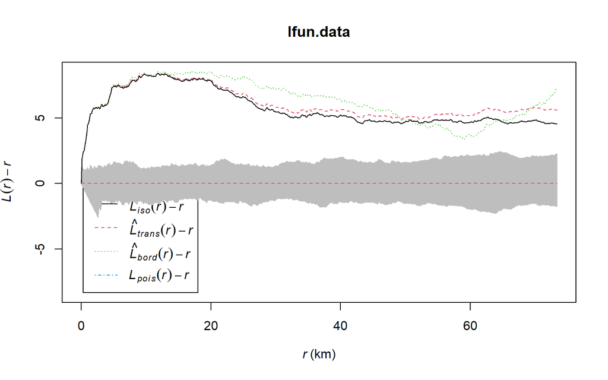

```r
#-----------------------------------------------------------------
# Calculate the L function and its uncertainty envelope
#-----------------------------------------------------------------
lfun.data <- Lest(ppp.fossils_km)

lenv.data <- envelope(ppp.fossils_km, Lest,
  correction = "Ripley",
  verbose = F,
  nsim = 200, nrank = 1,
  savepatterns = TRUE, savefuns = TRUE
)

#-----------------------------------------------------------------
# Plot the raw L-function data for different edge effects
#-----------------------------------------------------------------
plot(lfun.data, . - r ~ r,
  ylim = c(
    0 - (max(lfun.data$iso - lfun.data$r)),
    max(lfun.data - lfun.data$r)
  )
)
# Add the uncertainty envelope.
plot(lenv.data, . - r ~ r,
  add = TRUE
)
```

# Above & Beyond

**1.** Added additional `YAML` parameters including tags, category, and author affiliation

[figure not shown]

**2.** Used `stylr` package to automatically clean and format code chunks using the tidyverse style conventions. Also used `knitr::opts_chunk(strip.white = TRUE)` to remove leading and trailing empty lines

[figure not shown]

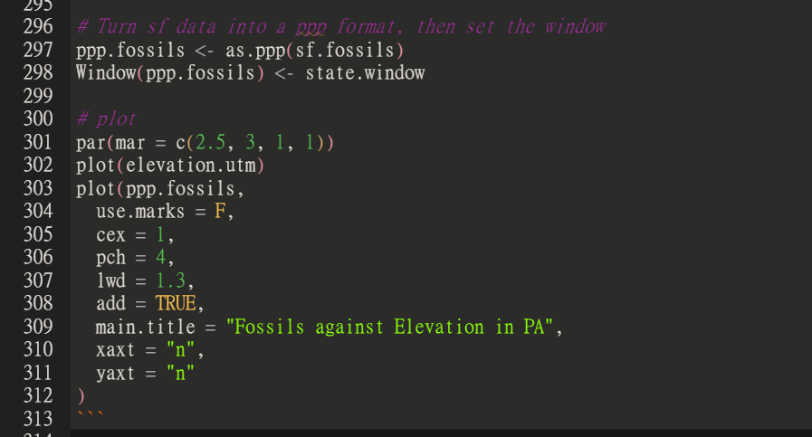

- Also want to mention the custom keyboard shortcuts I have been using, especially *insert chunk* and *redo* (default r assigns `ctrl+y` to multiple commands, so using the standard *redo* command requires removing the others)

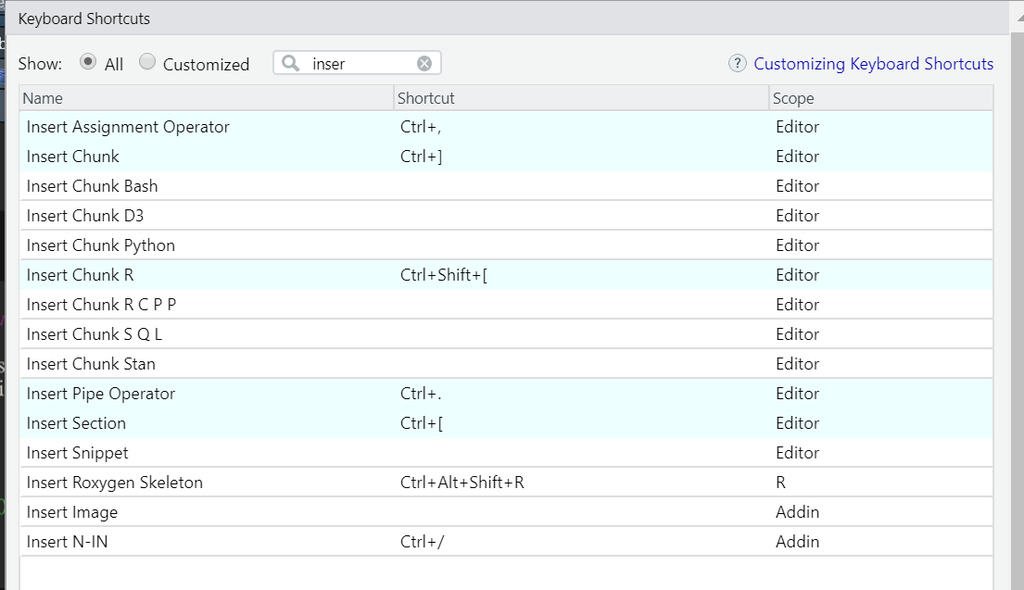

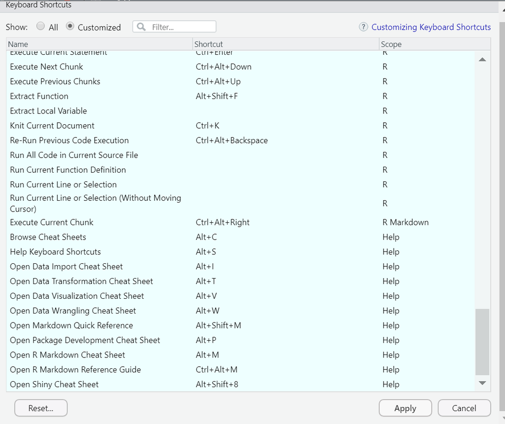

# References

Adrian Baddeley, Ege Rubak, Rolf Turner (2015). Spatial Point Patterns: Methodology and Applications with R. *London: Chapman and Hall/CRC Press*, 2015. URL https://www.routledge.com/Spatial-Point-Patterns-Methodology-and-Applications-with-R/Baddeley-Rubak-Turner/978482210200/

Bivand R, Lewin-Koh N (2022). *maptools: Tools for Handling Spatial Objects*. R package version 1.1-4, <https://CRAN.R-project.org/package=maptools>.

Hijmans R (2022). *raster: Geographic Data Analysis and Modeling*. R package version 3.5-29, <https://CRAN.R-project.org/package=raster>.

Hollister, J.W. (2021). elevatr: Access Elevation Data from Various APIs. R package version 0.4.1. https://CRAN.R-project.org/package=elevatr/

John Fox and Sanford Weisberg (2019). An {R} Companion to Applied Regression, Third Edition. Thousand Oaks CA: Sage. URL: https://socialsciences.mcmaster.ca/jfox/Books/Companion/

Lincoln A. Mullen and Jordan Bratt (2018), “USAboundaries: Historical and Contemporary Boundaries of the United States of America,” *Journal of Open Source Software 3*, (23):314, https://doi.org/10.21105/joss.00314.

Müller K, Walthert L (2022). *styler: Non-Invasive Pretty Printing of R Code*. R package version 1.8.1, <https://CRAN.R-project.org/package=styler>.

Neuwirth E (2022). *RColorBrewer: ColorBrewer Palettes*. R package version 1.1-3, <https://CRAN.R-project.org/package=RColorBrewer>.

Pebesma E, Mailund T, Hiebert J (2016). “Measurement Units in R.” *R Journal*, *8*(2), 486-494. doi:10.32614/RJ-2016-061.

Roger S. Bivand, Edzer Pebesma, Virgilio Gomez-Rubio, 2013. Applied spatial data analysis with R, Second edition. Springer, NY. https://asdar-book.org/

Tennekes M (2018). “tmap: Thematic Maps in R.” *Journal of Statistical Software*, *84*(6), 1-39. doi:10.18637/jss.v084.i06 <https://doi.org/10.18637/jss.v084.i06>.

Waring E, Quinn M, McNamara A, Arino de la Rubia E, Zhu H, Ellis S (2022). *skimr: Compact and Flexible Summaries of Data*. R package version 2.1.4, <https://CRAN.R-project.org/package=skimr>.

Wickham H, Averick M, Bryan J, Chang W, McGowan LD, François R, Grolemund G, Hayes A, Henry L, Hester J, Kuhn M, Pedersen TL, Miller E, Bache SM, Müller K, Ooms J, Robinson D, Seidel DP, Spinu V, Takahashi K, Vaughan D, Wilke C, Woo K, Yutani H (2019). “Welcome to the tidyverse.” *Journal of Open Source Software*, *4*(43), 1686. doi:10.21105/joss.01686.

Wickham H, François R, Henry L, Müller K (2022). *dplyr: A Grammar of Data Manipulation*. R package version 1.0.10, <https://CRAN.R-project.org/package=dplyr>.

Wickham H. (2016) ggplot2: Elegant Graphics for Data Analysis. Springer-Verlag New York.

Yihui Xie (2022). knitr: A General-Purpose Package for Dynamic Report Generation in R. R package version 1.40.